# cmetcalf_OriginalHomeworkCode_04

Cat Metcalf

2023-10-23

# What’s Your Malfunction?

## Question 1

Write a simple R function z.prop.test(), that can perform one- or two-sample Z-tests for proportion data, using the following guidelines:

-Your function should take the following arguments: p1 and n1 (no default) representing the estimated proportion and sample size (i.e., based on your sample data); p2 and n2 (both defaulting to NULL) that contain a second sample’s proportion and sample size data in the event of a two-sample test; p0 (no default) as the expected value for the population proportion; and alternative (default “two.sided”) and conf.level (default 0.95), to be used in the same way as in the function t.test().

-When conducting a two-sample test, it should be p1 that is tested as being smaller or larger than p2 when alternative=“less” or alternative=“greater”, the same as in the use of x and y in the function t.test().

-The function should perform a one-sample Z-test using p1, n1, and p0 if either p2 or n2 (or both) is NULL.

-The function should contain a check for the rules of thumb we have talked about (n∗p>5 and n∗(1−p)>5) to ensure the validity of assuming the normal distribution in both the one- and two-sample settings. If this is violated, the function should still complete but it should also print an appropriate warning message.

-The function should return a list containing the members Z (the test statistic), P (the appropriate p value), and CI (the two-sided CI with respect to “conf.level” around p1 in the case of a one-sample test and around p2-p1 in the case of a two-sample test). For all test alternatives (“two.sided”, “greater”, “less”), calculate symmetric CIs based on quantiles of the normal distribution rather than worrying about calculating single-limit confidence bounds.

**Our function is going to look something like this:** z.prop.test <- prop.test(x=c(sum(p1), sum(p2)), n= c(length(n1), length(n2)), conf.level = 0.95, alternative = c(“two.sided”, “less”, “greater”), correct = FALSE)

Where prop.test is indicating we are using the proportion test function. x= c(sum(p1), sum(p2)) is taking a vector of the sum of each estimated proportion to be considered if it is a 2 sample test, for one sample you would not run a vector but just take the sum of p1. n= c(length(n1), length(n2)) is taking a vector of the sample sizes for a two sample, where for one sample you would only take the length of n1. conf.level= 0.95 shows we want the 95% confidence level. alternative= c(“two.sided”, “less”, “greater”) is showing the options you can apply with this argument, so it would depend on whether you want a two-tailed test or one-tailed, so you would indicate one of these choices depending. correct = FALSE means that it using a large sample formula for the confidence interval, something usually applied for the possibility that data is not a normal distribution.

We can expect that this function will return a test statistic (shown by the notation “x-squared”), a p-value associated with the test statistic, a confidence interval, and sample estimates.

```r
z.prop.test <- function (p1, n1, p2, n2) {
  prop.test(x=c(sum(p1), sum(p2)), n= c(length(n1), length(n2)), conf.level = 0.95, alternative = c("two.sided", "less", "greater"), correct = FALSE)
}
```

```r
z.prop.test <- function(x,n,p=NULL,conf.level=0.95,alternative= c("two.sided", "less", "greater")) {
   Z <- NULL
   CI <- NULL
   p <- NULL
      x <- cbind(p1, p2 = NULL)
      n <- cbind(n1, n2= NULL)
      pstar <- (sum(p1) + sum(p2))/(length(p1) + length(p2)) #pooled proportion
      phat1 <- mean(p1) #proportion of successes in sample group p1
      phat2 <- mean(p2) #proportion of successes in sample group p2
      pi <- 0 #expected difference in proportions between sample groups (set to zero)
      z <- (phat2 - phat1)/sqrt((pstar * (1 - pstar)) * (1/length(n1) + 1/length(n2))) #formula for two sample z-test
      if(length(n1, n2) > 0) { #conducting confidence interval tailed tests dependent on whether it is two tailed or one tailed
         if(alternative=="two.sided") {
            p <- 1 - pnorm(z, lower.tail = TRUE) + pnorm(z, lower.tail = FALSE)
         }
         if(alternative=="greater") {
            p <- 1 - pnorm(z, lower.tail = TRUE)
         }
         if(alternative=="less") {
           p <- pnorm(z, lower.tail = FALSE)
         }
      } else {
     crit <- qnorm(1 - alpha/2)  # identify critical values
     test <- p < -crit || p > crit  # boolean test
      }
      CI <- phat + c(
         -1*((qnorm(((1 - conf.level)/2) + conf.level))*SE.phat),
         ((qnorm(((1 - conf.level)/2) + conf.level))*SE.phat) )
   return(list(estimate=z,p=p,CI=CI))
}
```

I used a one sample z.test created by someone as a template to work with forming my own function for this assignment since I struggled a lot with finding the correct syntax to use that was also easy to understand. It is found here: https://qualityandinnovation.com/2015/03/16/one-proportion-z-test-in-r/ .

*Still struggling with finding a way to do a one sample OR two sample, as well as applying the arguments with their certain conditions (Like the check for assuming normal, etc.). Any suggestions?

# Question 2

The dataset from Kamilar and Cooper has in it a large number of variables related to life history and body size. For this exercise, the end aim is to fit a simple linear regression model to predict longevity (MaxLongevity_m) measured in months from species’ brain size (Brain_Size_Species_Mean) measured in grams. Do the following for both longevity~brain size and log(longevity)~log(brain size):

-Fit the regression model and, using {ggplot2}, produce a scatterplot with the fitted line superimposed upon the data. Append the the fitted model equation to your plot (HINT: use the function geom_text()).

-Identify and interpret the point estimate of the slope (β1), as well as the outcome of the test associated with the hypotheses H0: β1 = 0; HA: β1 ≠ 0. Also, find a 90 percent CI for the slope (β1) parameter.

-Using your model, add lines for the 90 percent confidence and prediction interval bands on the plot and add a legend to differentiate between the lines.

-Produce a point estimate and associated 90 percent PI for the longevity of a species whose brain weight is 800 gm. Do you trust the model to predict observations accurately for this value of the explanatory variable? Why or why not?

-Looking at your two models, which do you think is better? Why?

First we have to load in the dataset:

```r
library(curl)
f <- curl("https://raw.githubusercontent.com/fuzzyatelin/fuzzyatelin.github.io/master/AN588_Fall23/KamilarAndCooperData.csv")
d <- read.csv(f, header = TRUE, sep = ",", stringsAsFactors = FALSE)
head(d)
```

```
##               Scientific_Name          Family          Genus      Species
## 1 Allenopithecus_nigroviridis Cercopithecidae Allenopithecus nigroviridis
## 2         Allocebus_trichotis Cercopithecidae      Allocebus    trichotis
## 3           Alouatta_belzebul        Atelidae       Alouatta     belzebul
## 4             Alouatta_caraya        Atelidae       Alouatta       caraya
## 5            Alouatta_guariba        Atelidae       Alouatta      guariba
## 6           Alouatta_palliata        Atelidae       Alouatta     palliata
##   Brain_Size_Species_Mean Brain_Size_Female_Mean   Brain_size_Ref
## 1                   58.02                  53.70 Isler et al 2008
## 2                      NA                     NA
## 3                   52.84                  51.19 Isler et al 2008
## 4                   52.63                  47.80 Isler et al 2008
## 5                   51.70                  49.08 Isler et al 2008
## 6                   49.88                  48.04 Isler et al 2008
##   Body_mass_male_mean Body_mass_female_mean Mass_Dimorphism
```

[output cut: 62 more lines]

Next load in ggplot and manipulate:

```r
library(ggplot2)
library(ggpmisc)
library(manipulate)
```

Using an example from Module 12 we can find a line of best fit for a regression model:

```r
model <- lm(MaxLongevity_m ~ Brain_Size_Species_Mean, data=d)
model #finds linear regression line of best fit, as well as the intercep tbeing beta0 and the remaining coefficient is beta1
```

```
##
## Call:
## lm(formula = MaxLongevity_m ~ Brain_Size_Species_Mean, data = d)
##
## Coefficients:
##             (Intercept)  Brain_Size_Species_Mean
##                 248.952                    1.218
```

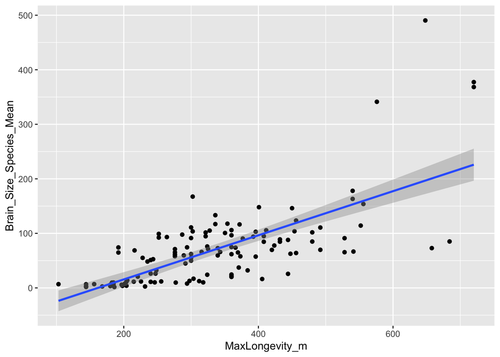

```r
g <- ggplot(data = d, aes(x = MaxLongevity_m, y = Brain_Size_Species_Mean))
g <- g + geom_point()
g <- g + geom_smooth(method = "lm", formula = y ~ x)
g <- g + stat_poly_line(formula = model)
g <- g + stat_poly_eq(mapping = aes(label = after_stat(eq.label)), formula = model)
g #plots points with line of best fit
```

I can not seem to find a way to make it display an equation when i try to insert it and it just seems to label each point? Any suggestions are helpful.

```r
ci <- confint(model, level = 0.90)  # using the results of lm()
ci
```

```
##                                5 %      95 %
## (Intercept)             230.540738 267.36379
## Brain_Size_Species_Mean   1.035571   1.40041
```